# Neural Networks

Shaobo Li

April, 2019

```r
# load Boston data
library(MASS)
library(tidyverse)
data(Boston)
index <- sample(nrow(Boston),nrow(Boston)*0.70)
boston.train <- Boston[index,]
boston.test <- Boston[-index,]

# load credit card data
credit.data <- read.csv("http://homepages.uc.edu/~lis6/DataMining/Data/credit_default.csv", header=T)
credit.data<- rename(credit.data, default=default.payment.next.month)
# convert categorical data to factor
credit.data$SEX<- as.factor(credit.data$SEX)
credit.data$EDUCATION<- as.factor(credit.data$EDUCATION)
credit.data$MARRIAGE<- as.factor(credit.data$MARRIAGE)
# random splitting
index <- sample(nrow(credit.data),nrow(credit.data)*0.80)
credit.train = credit.data[index,]
credit.test = credit.data[-index,]

# load MNIST data
digit<- data.matrix(read_csv("https://www.dropbox.com/s/ulujvi2a4ykfzju/train.csv?dl=1"))
# random splitting
index<- sample(1:nrow(digit), 0.6*nrow(digit))
train<- digit[index,]
test<- digit[-index,]
# standardize X
train.x <- train[,-1] #remove 'label' column
test.x<- test[,-1]
train.y <- train[,1] #label column
test.y<- test[,1]
train.x <- train.x/255
test.x <- test.x/255
```

# Neural network with package `neuralnet`

The R package `neuralnet` is available to fit simple (less hidden layers) artifical neural network models. One good thing about this package is that user can visualize the fitted neural networks as well as the weights.

```r
library(neuralnet)
```

## ANN for regression.

We use our familiar Boston housing data for demonstration. **Note, the response variable has to be rescaled to (0,1) range**, and predictors are recommended to be standardized as well.

```r
boston.train[,-14]<- as.data.frame(scale(boston.train[,-14]))
boston.train$medv<- boston.train$medv/50
boston.test[,-14]<- as.data.frame(scale(boston.test[,-14]))
```

```r
# fit neural network with one hidden layer
boston.ann1<- neuralnet(medv~., data = boston.train, hidden = 5, linear.output = TRUE)
#Plot the neural network
plot(boston.ann1)
```

Prediction on testing sample.

```r
boston.pred1<- compute(boston.ann1, boston.test)
boston.pred1<- boston.pred1$net.result*50
mean((boston.test$medv-boston.pred1)^2)
```

```
## [1] 16.79655
```

Let’s add another hidden layer.

```r
# fit neural network with one hidden layer
boston.ann2<- neuralnet(medv~., data = boston.train, hidden = c(5,5), linear.output = TRUE)
#Plot the neural network
plot(boston.ann2)
```

Prediction on testing sample.

```r
boston.pred2<- compute(boston.ann2, boston.test)
boston.pred2<- boston.pred2$net.result*50
mean((boston.test$medv-boston.pred2)^2)
```

```
## [1] 14.31254
```

### Comparing with linear regression.

```r
boston.reg<- lm(medv~., data = boston.train)
boston.reg.pred<- predict(boston.reg, newdata = boston.test)*50
mean((boston.test$medv-boston.reg.pred)^2)
```

```
## [1] 19.92852
```

### How many neurons are good for one hidden layer nn?

#### Exercise: implement CV to select the number of neurons.

Back to top

## ANN for Classification

First standardize the data and create dummy variables for categorical data.

```r
credit.train.X<- as.data.frame(scale(model.matrix(~., data = credit.train[,-ncol(credit.train)])[,-1]))
credit.train.Y<- credit.train[,ncol(credit.train)]
credit.train1<- data.frame(default= credit.train.Y, credit.train.X)
credit.test1<- as.data.frame(scale(model.matrix(~., data = credit.test[,-ncol(credit.train)])[,-1]))
```

```r
# fit neural networks. CAUTION: this is slow
credit.ann<- neuralnet(default~., data = credit.train1, hidden = 3, linear.output = FALSE)
plot(credit.ann)
```

#### Prediction on testing sample.

```r
credit.pred1<- compute(credit.ann, credit.test1)
head(cbind(credit.test$default, credit.pred1$net.result), 10)
```

```
##    [,1]       [,2]
## 2     0 0.20278440
## 3     0 0.07109528
## 10    0 0.07591105
## 18    1 0.15840511
## 26    0 0.07167220
## 27    1 0.60221535
## 35    0 0.51898587
## 46    0 0.14536099
## 47    0 0.07018660
## 50    1 0.20932771
```

#### ROC curve and AUC

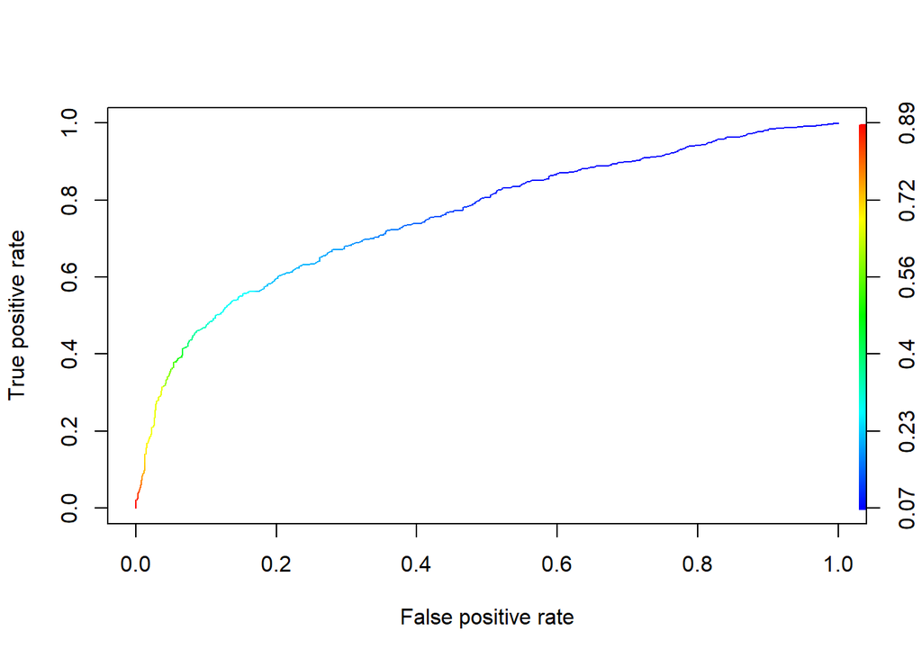

```r
library(ROCR)
pred <- prediction(credit.pred1$net.result, credit.test$default)
perf <- performance(pred, "tpr", "fpr")
plot(perf, colorize=TRUE)
```

```r
#Get the AUC
unlist(slot(performance(pred, "auc"), "y.values"))
```

```
## [1] 0.7578039
```

#### Confusion matrix

```r
credit.pred01.ann<- (credit.pred1$net.result>mean(credit.train$default))*1
#Confusion matrix
table(credit.test$default, credit.pred01.ann, dnn=c("Truth","Predicted"))
```

```
##      Predicted
## Truth    0    1
##     0 1444  423
##     1  202  331
```

```r
# MR, FPR, FNR
c(mean(credit.test$default != credit.pred01.ann),
sum(credit.test$default ==0 & credit.pred01.ann==1)/sum(credit.test$default ==0),
sum(credit.test$default ==1 & credit.pred01.ann==0)/sum(credit.test$default ==1)
)
```

```
## [1] 0.2604167 0.2265667 0.3789869
```

### Comparing with logistic model

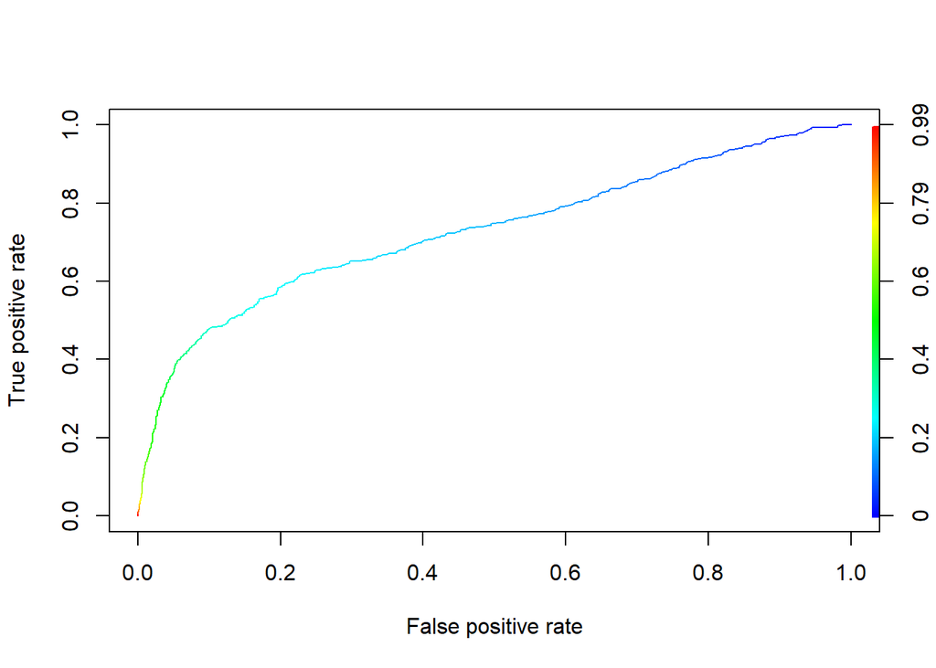

```r
#Fit logistic regression model
credit.glm<- glm(default~., data = credit.train, family=binomial)
#Get prediction
credit.pred.glm<- predict(credit.glm, credit.test, type="response")
# obtain ROC curve
pred <- prediction(credit.pred.glm, credit.test$default)
perf <- performance(pred, "tpr", "fpr")
plot(perf, colorize=TRUE)
```

```r
#Get the AUC
unlist(slot(performance(pred, "auc"), "y.values"))
```

```
## [1] 0.728378
```

#### Confusion matrix

```r
credit.pred01.glm<- (credit.pred.glm>mean(credit.train$default))*1
#Confusion matrix
table(credit.test$default, credit.pred01.glm, dnn=c("Truth","Predicted"))
```

```
##      Predicted
## Truth    0    1
##     0 1269  598
##     1  184  349
```

```r
# MR, FPR, FNR
c(mean(credit.test$default != credit.pred01.glm),
sum(credit.test$default ==0 & credit.pred01.glm==1)/sum(credit.test$default ==0),
sum(credit.test$default ==1 & credit.pred01.glm==0)/sum(credit.test$default ==1)
)
```

```
## [1] 0.3258333 0.3202999 0.3452158
```

Back to top

## Deep learning with `MXNet`

This part of notes are based on a Kaggle Kernel at [here](https://www.kaggle.com/srlmayor/easy-neural-network-in-r-for-0-994).

For window users, please type the code below to install `mxnet` package.

```r
cran <- getOption("repos")
cran["dmlc"] <- "https://apache-mxnet.s3-accelerate.dualstack.amazonaws.com/R/CRAN/"
options(repos = cran)
install.packages("mxnet")
```

```r
library(mxnet)
```

#### Visualize the data

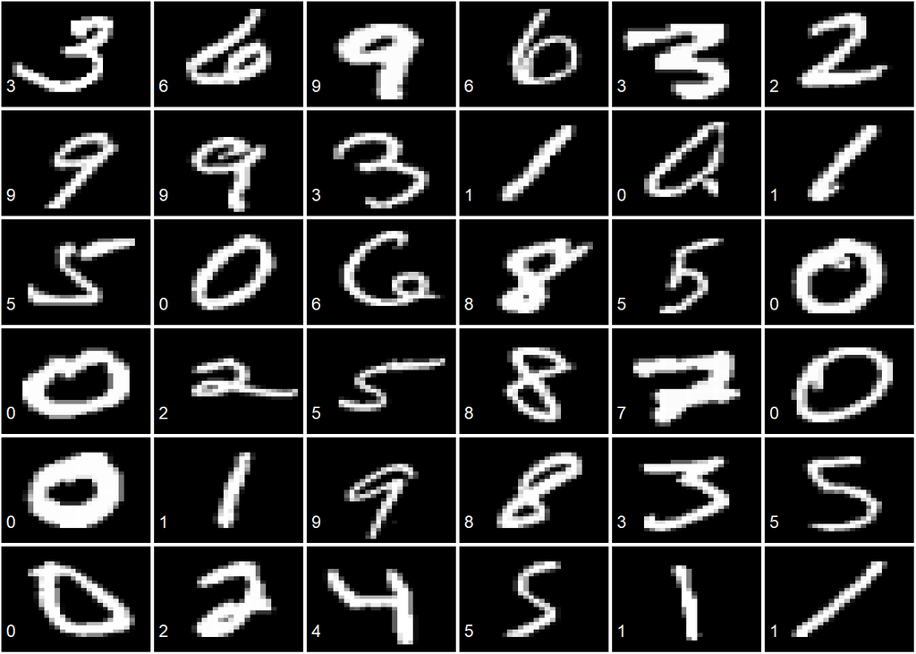

```r
plotTrain <- function(images){
  op <- par(no.readonly=TRUE)
  x <- ceiling(sqrt(length(images)))
  par(mfrow=c(x, x), mar=c(.1, .1, .1, .1))

  for (i in images){ #reverse and transpose each matrix to rotate images
    m <- matrix(train[i,-1], nrow=28, byrow=TRUE)
    m <- apply(m, 2, rev)
    image(t(m), col=gray((0:255)/255), axes=FALSE)
    text(0.05, 0.2, col="white", cex=1.2, train[i, 1])
  }
  par(op) #reset the original graphics parameters
}

plotTrain(1:36)
```

### Building A Simple Neural Network

We need to specify each layer with number of neurons and the activation functions. We specify the activation functions in first two layers as “ReLU” (Rectified Linear Unit), while the activation function on the output layer to be “softmax” because we have multiple classes.

For more information, I recommend checking out the [MXNet tutorial page](http://mxnet.io).

```r
m1.data <- mx.symbol.Variable("data") # Notice how each layer is passed to the next

m1.fc1 <- mx.symbol.FullyConnected(m1.data, name="fc1", num_hidden=128)
m1.act1 <- mx.symbol.Activation(m1.fc1, name="activation1", act_type="relu")

m1.fc2 <- mx.symbol.FullyConnected(m1.act1, name="fc2", num_hidden=64)
m1.act2 <- mx.symbol.Activation(m1.fc2, name="activation2", act_type="relu")

m1.fc3 <- mx.symbol.FullyConnected(m1.act2, name="fc3", num_hidden=10)
m1.softmax <- mx.symbol.SoftmaxOutput(m1.fc3, name="softMax")
```

MXNet can make use of the Graphviz package to create an interactive plot of the structure of the network. This one is nothing fancy, but they can be quite useful if your network is [complex](http://josephpcohen.com/w/visualizing-cnn-architectures-side-by-side-with-mxnet).

```r
graph.viz(m1.softmax)
```

[interactive chart not shown]

### Train the Neural Network

By default, it trains the model using CPU, but it is really fast. If GPU is used, it would be 50+ times faster! However, you have to install the [GPU version](http://mxnet.io/get_started/index.html#installation) of the package yourself.

```r
devices <- mx.cpu()  # decide which device to use
#log <- mx.metric.logger$new() #to keep track of the results each iterration
tick <- proc.time() #mark the start time
mx.set.seed(0)

mxnet1 <- mx.model.FeedForward.create(m1.softmax,  #the network configuration made above
                                     X = t(train.x), #the predictors (need transpose)
                                     y = train.y, #the labels
                                     ctx = devices,
                                     num.round = 20, # number of training iterations
                                     array.batch.size = 100,
                                     array.layout="colmajor",
                                     learning.rate = 0.01,
                                     momentum = 0.95,
                                     eval.metric = mx.metric.accuracy,
                                     initializer = mx.init.uniform(0.07),
                                     epoch.end.callback = mx.callback.log.train.metric(100)
)


print(paste("Training took:", round((proc.time() - tick)[3],2),"seconds"))
```

```
## [1] "Training took: 7.79 seconds"
```

### Prediction

```r
preds <- predict(mxnet1, test.x)
dim(preds)
```

```
## [1]    10 16800
```

```r
pred.label <- max.col(t(preds)) - 1
table(pred.label)
```

```
## pred.label
##    0    1    2    3    4    5    6    7    8    9
## 1635 1840 1584 1819 1657 1479 1607 1825 1603 1751
```

```r
mean(pred.label==test.y)
```

```
## [1] 0.9640476
```

Back to top